```python
import pandas as pd
import numpy as np
import matplotlib.pyplot as plt
import seaborn as sns
```

# Introduction & Problem Statement

EPA, or Expected Points Added is a statistical measure designed to rationalize a players performance on the field. It is generally thought of as either a QB-centric measure or a measure of the overall offenses performance. Analysts and pundits often use it to compare two different offensive systems, two different QBs performance or summarize a teams performance in a game.

EPA is relatively simple to conceptualize. For every play in the NFL there are two states - the before-play state and the after-play state. 1st and 10 vs. 2nd and 5. Comparing the expected points generated by the offense in the before and after play state enables an analyst to rationalize the expected points that the offense has added during the play, hence "Expected Points Added". The two states expected points can be calculated by comparing the points generated on all other offensive drives, from a historical dataset, given the same down, distance, time-remaining in the game, etc.

I'll discuss why I think EPA is sometimes misunderstood and give some examples of it's limitations.

There are a lot of different implementations of EPA using different methodologies. Other information and further reading can be found https://www.opensourcefootball.com/posts/2020-09-28-nflfastr-ep-wp-and-cp-models/#ep-model-features and https://arxiv.org/pdf/1802.00998.pdf.

The original paper can be found at https://pubsonline.informs.org/doi/pdf/10.1287/opre.19.2.541

# Implementation of Web-Scraping Functions

The first task is to get NFL play-by-play data. There are many different sources of this data but we will use NFLFastR, which is a tremdendous resource that has multiple different levels of information as well as a plethora of fields that can be used for analytics. More information can be found at https://github.com/nflverse/nflfastR.

```python
def get_play_by_play_data(years = ['2020']):
    data = pd.DataFrame()
    for year in years:
        i_data = pd.read_csv('https://github.com/nflverse/nflverse-data/releases/download/pbp/' \
                   'play_by_play_' + str(year) + '.csv.gz',
                   compression= 'gzip', low_memory= False)
        data = data.append(i_data, sort=True)
        data.reset_index(drop=True, inplace=True)
    return data
```

```python
pbp_data_frame = get_play_by_play_data(years = ['2016','2017','2018','2019','2020','2021','2022'])
```

# Commentary on Data Needed to Implement EPA

This contextual pieces of data can be used to set the state of the game and determine the expected points of a particular offensive situation on the field. It should be noted that multiple different types of implementations have been proposed (https://www.opensourcefootball.com/posts/2020-09-28-nflfastr-ep-wp-and-cp-models/#ep-model-features,https://arxiv.org/pdf/1802.00998.pdf)

Additionally, when calculating total EPA, we have to consider the results of transitions. For example, if the offensive team punts - not only are they not generating any points, but they are also indirectly incurring points against. This is because of the expected points that the formerly defensive team will score against the punting team.

# Cleaning up our Dataset

```python
#remove all rows that are special teams, two minute warnings etc. etc.
relevant_plays = ['pass','run','punt','fieldgoal','qb_spike']
pbp_data_frame = pbp_data_frame.loc[pbp_data_frame['play_type'].isin(relevant_plays)]
pbp_data_frame.reset_index(inplace = True)
```

# Implementation of State-Based EPA

```python
#extract all unique game states from the dataframe - this includes kickoffs, timeouts, end of half, two minute warnings etc.
nfl_states = pbp_data_frame.drop_duplicates(subset=['half_seconds_remaining','yardline_100','posteam_type','roof','down','goal_to_go','ydstogo','posteam_timeouts_remaining','defteam_timeouts_remaining'], keep='first')
nfl_states = nfl_states[['half_seconds_remaining','yardline_100','posteam_type','roof','down','goal_to_go','ydstogo','posteam_timeouts_remaining','defteam_timeouts_remaining']]
nfl_states.reset_index(inplace = True)
```

```python
#drive data
nfl_drives = pbp_data_frame.drop_duplicates(subset=['game_id','drive','drive_end_transition'], keep='first')[['game_id','drive','drive_end_transition']]
```

```python
pbp_data_frame['drive_points']  = np.where(pbp_data_frame['drive_end_transition'] == 'TOUCHDOWN', 7,
                                    np.where(pbp_data_frame['drive_end_transition'] == 'FIELD_GOAL', 3,
                                    np.where(pbp_data_frame['drive_end_transition'] == 'SAFETY', -2,
                                    np.where(pbp_data_frame['drive_end_transition'] == 'FUMBLE_SAFETY', -2, 0))))
nfl_states['plays_in_state'] = 0
nfl_states['points_added'] = 0
```

```python
for index, row in pbp_data_frame.iterrows():
    target_index = np.where((nfl_states['half_seconds_remaining'] == row['half_seconds_remaining']) &
                        (nfl_states['yardline_100']== row['yardline_100']) &
                        (nfl_states['posteam_type']== row['posteam_type']) &
                        (nfl_states['roof']== row['roof']) &
                        (nfl_states['down']== row['down']) &
                        (nfl_states['goal_to_go']== row['goal_to_go']) &
                        (nfl_states['ydstogo']== row['ydstogo']) &
                        (nfl_states['posteam_timeouts_remaining']== row['posteam_timeouts_remaining']) &
                        (nfl_states['defteam_timeouts_remaining']== row['defteam_timeouts_remaining']))
    if len(target_index[0]) == 0:
            pass
    else:
        nfl_states.at[target_index[0][0], 'points_added'] += row['drive_points']
        nfl_states.at[target_index[0][0], 'plays_in_state'] += 1

relevant_outcomes = ['TOUCHDOWN','FIELD_GOAL','SAFETY','FUMBLE_SAFETY']
for index, row in pbp_data_frame.iterrows():
    #if the drive ends in a touchdown, fieldgoal, end_game, end_half - we do not care
    if (row['drive_end_transition'] == 'TOUCHDOWN')\
    | (row['drive_end_transition'] == 'FIELD_GOAL')\
    | (row['drive_end_transition'] == 'END_GAME')\
    | (row['drive_end_transition'] == 'END_HALF'):
        pass
    else:
        #check to see what the next drives result was
        try:
            if (nfl_drives.loc[(nfl_drives['drive'] == (row['drive']+1)) & (nfl_drives['game_id'] == row['game_id']),['drive_end_transition']].values[0][0] == 'TOUCHDOWN')\
            | (nfl_drives.loc[(nfl_drives['drive'] == (row['drive']+1)) &\
                            (nfl_drives['game_id'] == row['game_id']),['drive_end_transition']].values[0][0] == 'FIELD_GOAL')\
            |(nfl_drives.loc[(nfl_drives['drive'] == (row['drive']+1)) &\
                            (nfl_drives['game_id'] == row['game_id']),['drive_end_transition']].values[0][0] == 'SAFETY')\
            |(nfl_drives.loc[(nfl_drives['drive'] == (row['drive']+1)) &\
                            (nfl_drives['game_id'] == row['game_id']),['drive_end_transition']].values[0][0] == 'FUMBLE_SAFETY'):

                target_index = np.where((nfl_states['half_seconds_remaining'] == row['half_seconds_remaining']) &
                            (nfl_states['yardline_100']== row['yardline_100']) &
                            (nfl_states['posteam_type']== row['posteam_type']) &
                            (nfl_states['roof']== row['roof']) &
                            (nfl_states['down']== row['down']) &
                            (nfl_states['goal_to_go']== row['goal_to_go']) &
                            (nfl_states['ydstogo']== row['ydstogo']) &
                            (nfl_states['posteam_timeouts_remaining']== row['posteam_timeouts_remaining']) &
                            (nfl_states['defteam_timeouts_remaining']== row['defteam_timeouts_remaining']))
                if len(target_index[0]) == 0:
                    pass
                else:
                    nfl_states.at[target_index[0][0], 'points_added'] -= row['drive_points']
                    nfl_states.at[target_index[0][0], 'plays_in_state'] += 1
        except:
            pass
```

```python
nfl_states['EPA'] = nfl_states['points_added'] / nfl_states['plays_in_state']
```

# Limitations of State-Based EPA & Next Steps

I will start by acknowledging that there are other ways to implement EPA, with different factors. However, there are several limitations of this implementation of EPA, which in my research, is generally used in practice. I don't believe these limitations are well communicated by the nfl analytics community. It is often used as a black and white measure of an offense or a QB, which isn't the case. Although an excellent way to get a sense of the performance of an offense as a whole or perhaps even a plays impact on the ability to generate points on a drive - I do not believe it is a comprehensive summarization of an offenses ability or a players impact on the game. I'll highlight a couple of factors that I believe should be considered when using EPA:

**Equivalent Weighting of Halfs**

Firstly, it omits key contextual information about the current state of the game. For example, teams that are up by several touchdowns late in a game will have the same EP as a team that is down several touchdowns late in a game. This means that aggressive (see: reckless) playcalling could be rewarded in late game scenarios in terms of EPA. Lets use a simple example. In 2009, the Patriots were up 45-0 at the end of first half against the Titans. At the beginning of the 2nd half, the Patriots had the game essentially in hand. However, from an EP standpoint - we might expect to see negative EPA if the Patriots continiously ran and played a conservative game. This methodology of EPA treats a game with a 45-0 score at the beginning of the second half equivalently to a 0-0 score at the beginning of the first half!

https://www.espn.com/nfl/game/_/gameId/291018017

**The Nature of Play-Calling**  
Playcalling is not executed in a single-play vacuum. The objective of a play-caller may appear to be maximizing yards or likelihood to score, but it is also a proverbial jab. Playcallers will dial up specific concepts and formations in order to test what a defense is doing and how they react to certain situations.

An offensive playcaller (a good one) will likely be calling plays designed not just to generate yards, but also to set up defenses for bigger plays later in the process. Play-action is a great example of it. If the defense knows that you won't run the ball - the linebackers are very unlikely to bite.

An argument can be made that the EPA generated through subsequent playcalling could represent this planning - in practice it is unlikely that one could discern this from the statistics themselves. Understanding the *why* behind playcalling can help explain offensive performance in a way that EPA does not capture.

# Visualizing EPA

```python
nfl_states['plays_in_state'].value_counts()
```

```
1      28659
2       6852
0        139
3         76
4         21
5          3
38         2
6          2
137        1
135        1
35         1
22         1
Name: plays_in_state, dtype: int64
```

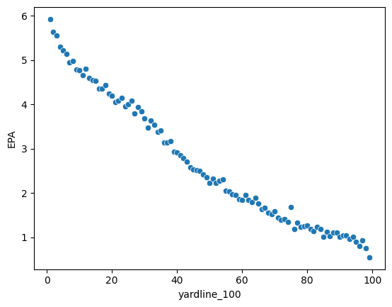

```python
sns.scatterplot(y = nfl_states.groupby('yardline_100').mean()['EPA'], x = nfl_states.groupby('yardline_100').mean().index)
```

# Bringing it all home

EPA is a tremendous analytical rationalization of offensive (and defensive performance). As with all advanced statistics, I think it is very important to understand what is actually going into the metric before using it. To be clear, I believe in the value of EPA, but I do believe that it is sometimes used in a manner that is disingenous to the actual performance of players on the field. Frankly, that is not a critique of EPA, but rather a critique of the usage of EPA. As an analyst, you have to understand the limitations of your work, accept those limitations and communicate those limitations to your end-users.